# Section 4: Genomic annotation with Bioconductor

Haeun Lee

2026-01-03

```r
# Bioconductor packages
BiocManager::install(c("BSgenome",
                       "BSgenome.Hsapiens.UCSC.hg19.masked",
                       "org.Hs.eg.db",
                       "ensembldb",
                       "EnsDb.Hsapiens.v75",
                       "AnnotationHub",
                       "rtracklayer",
                       "TxDb.Hsapiens.UCSC.hg38.knownGene",
                       "KEGGREST",
                       "rols",
                       "GSEABase"))
```

```
## Bioconductor version 3.16 (BiocManager 1.30.27), R 4.2.3 (2023-03-15)
```

[output not shown]

```r
# CRAN packages
# install.packages(c("R.utils",
#                    "png",
#                    "DT"))
```

# Annotation of genes and transcripts

## Reference sequence packages for model organisms

```r
library(BSgenome)
library(Biostrings)
# reference genomes
ag = available.genomes()
grep("Scerev", ag, value=TRUE)
```

```
## [1] "BSgenome.Scerevisiae.UCSC.sacCer1" "BSgenome.Scerevisiae.UCSC.sacCer2"
## [3] "BSgenome.Scerevisiae.UCSC.sacCer3"
```

```r
grep("Hsap", ag, value=TRUE)
```

```
##  [1] "BSgenome.Hsapiens.1000genomes.hs37d5"
##  [2] "BSgenome.Hsapiens.NCBI.GRCh38"
##  [3] "BSgenome.Hsapiens.NCBI.T2T.CHM13v2.0"
##  [4] "BSgenome.Hsapiens.UCSC.hg17"
##  [5] "BSgenome.Hsapiens.UCSC.hg17.masked"
##  [6] "BSgenome.Hsapiens.UCSC.hg18"
##  [7] "BSgenome.Hsapiens.UCSC.hg18.masked"
##  [8] "BSgenome.Hsapiens.UCSC.hg19"
##  [9] "BSgenome.Hsapiens.UCSC.hg19.masked"
## [10] "BSgenome.Hsapiens.UCSC.hg38"
## [11] "BSgenome.Hsapiens.UCSC.hg38.dbSNP151.major"
## [12] "BSgenome.Hsapiens.UCSC.hg38.dbSNP151.minor"
## [13] "BSgenome.Hsapiens.UCSC.hg38.masked"
## [14] "BSgenome.Hsapiens.UCSC.hs1"
```

```r
# inspect the human genome
library(BSgenome.Hsapiens.UCSC.hg19)
Hsapiens
```

```
## Human genome:
## # organism: Homo sapiens (Human)
## # genome: hg19
## # provider: UCSC
## # release date: June 2013
## # 298 sequences:
## #   chr1                  chr2                  chr3
## #   chr4                  chr5                  chr6
## #   chr7                  chr8                  chr9
## #   chr10                 chr11                 chr12
## #   chr13                 chr14                 chr15
## #   ...                   ...                   ...
## #   chr19_gl949749_alt    chr19_gl949750_alt    chr19_gl949751_alt
## #   chr19_gl949752_alt    chr19_gl949753_alt    chr20_gl383577_alt
## #   chr21_gl383578_alt    chr21_gl383579_alt    chr21_gl383580_alt
## #   chr21_gl383581_alt    chr22_gl383582_alt    chr22_gl383583_alt
## #   chr22_kb663609_alt
## # (use 'seqnames()' to see all the sequence names, use the '$' or '[[' operator
## # to access a given sequence)
```

```r
length(Hsapiens)
```

```
## [1] 298
```

```r
class(Hsapiens)
```

```
## [1] "BSgenome"
## attr(,"package")
## [1] "BSgenome"
```

```r
methods(class="BSgenome")
```

```
##  [1] [[              $               as.list         bsgenomeName
##  [5] coerce          commonName      countPWM        export
##  [9] extractAt       getSeq          injectSNPs      length
## [13] masknames       matchPWM        metadata        metadata<-
## [17] mseqnames       names           organism        provider
## [21] providerVersion releaseDate     seqinfo         seqinfo<-
## [25] seqnames        seqnames<-      show            snpcount
## [29] SNPlocs_pkgname snplocs         sourceUrl       vcountPattern
## [33] vcountPDict     Views           vmatchPattern   vmatchPDict
## see '?methods' for accessing help and source code
```

```r
# inspect human genome
Hsapiens$chrX
```

```
## 155270560-letter DNAString object
## seq: NNNNNNNNNNNNNNNNNNNNNNNNNNNNNNNNNNNN...NNNNNNNNNNNNNNNNNNNNNNNNNNNNNNNNNNNN
```

```r
substr(Hsapiens$chrX, 5e6, 5.1e6)
```

```
## 100001-letter DNAString object
## seq: GCCTCAATGTCAGAATTATGCTGTTGCCCAAAATTG...TACTAAAAATACAAAAATTAGCTGGGCATGGTGGTG
```

```r
nchar(Hsapiens$chrY)
```

```
## [1] 59373566
```

```r
nchar(Hsapiens[[24]])
```

```
## [1] 59373566
```

In Biostrings, a pile of masks can be put on top of a sequence. A pile of masks is represented by a MaskCollection object and the sequence by an XString object. A MaskedXString object is the result of bundling them together in a single object.

### Assessment

Genomic sequence “mask” structures have been defined to isolate ambiguous, unmappable, and low-complexity segments of genomes so that sequence analysis research can be targeted to reflect current knowledge of sequence regions that are more likely to be functionally informative.

```r
library(BSgenome)
grep("mask", grep("Drerio", available.genomes(), value=TRUE), invert=TRUE, value=TRUE) # exclude masked
```

```
## [1] "BSgenome.Drerio.UCSC.danRer10" "BSgenome.Drerio.UCSC.danRer11"
## [3] "BSgenome.Drerio.UCSC.danRer5"  "BSgenome.Drerio.UCSC.danRer6"
## [5] "BSgenome.Drerio.UCSC.danRer7"
```

```r
library(BSgenome.Hsapiens.UCSC.hg19.masked)
# original sequence is always stored unmodified in a MaskedXString object
c17m = BSgenome.Hsapiens.UCSC.hg19.masked$chr17
c17 = BSgenome.Hsapiens.UCSC.hg19$chr17 # contain 'unmasked' from c17m only

class(c17m)
```

```
## [1] "MaskedDNAString"
## attr(,"package")
## [1] "Biostrings"
```

```r
c22m = BSgenome.Hsapiens.UCSC.hg19.masked$chr22
print(c22m)
```

```
## 51304566-letter MaskedDNAString object (# for masking)
## seq: ####################################...####################################
## masks:
##   maskedwidth  maskedratio active names                               desc
## 1    16410000 3.198546e-01   TRUE AGAPS                      assembly gaps
## 2          21 4.093203e-07   TRUE   AMB           intra-contig ambiguities
## 3    17230953 3.358561e-01  FALSE    RM                       RepeatMasker
## 4      377637 7.360690e-03  FALSE   TRF Tandem Repeats Finder [period<=12]
## all masks together:
##   maskedwidth maskedratio
##      33664642   0.6561724
## all active masks together:
##   maskedwidth maskedratio
##      16410021    0.319855
```

```r
maskedratio(c22m)*100
```

```
## [1] 31.9855
```

```r
# OR
# the masks of assembly gaps, aka “the AGAPS masks”;
# the masks of intra-contig ambiguities, aka “the AMB masks”;
# the masks of repeat regions that were determined by the RepeatMasker software, aka “the RM masks”;
# the masks of repeat regions that were determined by the Tandem Repeats Finder software (where only repeats with period less than or equal to 12 were kept), aka “the TRF masks”
round(100*sum(width(masks(c22m)$AGAPS))/length(c22m),0)
```

```
## [1] 32
```

## Packages for gene and transcript catalogs

Information about reference genome regions like genes, transcripts and exons can also be found in annotation packages. One major source of reference genome structure annotation is the UCSC Genome Browser.

```r
# import TxDb transcript database
library(TxDb.Hsapiens.UCSC.hg19.knownGene)
txdb = TxDb.Hsapiens.UCSC.hg19.knownGene  # abbreviate
class(txdb) # GenomicFeatures
```

```
## [1] "TxDb"
## attr(,"package")
## [1] "GenomicFeatures"
```

```r
methods(class="TxDb")
```

```
##  [1] $                      $<-                    annotatedDataFrameFrom
##  [4] as.list                asBED                  asGFF
##  [7] assayData              assayData<-            cds
## [10] cdsBy                  cdsByOverlaps          coerce
## [13] columns                combine                contents
## [16] dbconn                 dbfile                 dbInfo
## [19] dbmeta                 dbschema               disjointExons
## [22] distance               exons                  exonsBy
## [25] exonsByOverlaps        ExpressionSet          extractUpstreamSeqs
## [28] featureNames           featureNames<-         fiveUTRsByTranscript
## [31] genes                  initialize             intronsByTranscript
## [34] isActiveSeq            isActiveSeq<-          isNA
## [37] keys                   keytypes               mapIds
## [40] mapIdsToRanges         mappedkeys             mapRangesToIds
## [43] mapToTranscripts       metadata               microRNAs
## [46] nhit                   organism               promoters
## [49] revmap                 sample                 sampleNames
## [52] sampleNames<-          saveDb                 select
## [55] seqinfo                seqinfo<-              seqlevels<-
## [58] seqlevels0             show                   species
## [61] storageMode            storageMode<-          taxonomyId
## [64] threeUTRsByTranscript  transcripts            transcriptsBy
## [67] transcriptsByOverlaps  tRNAs                  updateObject
## see '?methods' for accessing help and source code
```

```r
# extract and inspect genes from TxDb
# returns a GRanges. Each range corresponds to a gene.
genes(txdb)
```

```
##   403 genes were dropped because they have exons located on both strands
##   of the same reference sequence or on more than one reference sequence,
##   so cannot be represented by a single genomic range.
##   Use 'single.strand.genes.only=FALSE' to get all the genes in a
##   GRangesList object, or use suppressMessages() to suppress this message.
```

```
## GRanges object with 23056 ranges and 1 metadata column:
##         seqnames              ranges strand |     gene_id
##            <Rle>           <IRanges>  <Rle> | <character>
##       1    chr19   58858172-58874214      - |           1
##      10     chr8   18248755-18258723      + |          10
##     100    chr20   43248163-43280376      - |         100
##    1000    chr18   25530930-25757445      - |        1000
##   10000     chr1 243651535-244006886      - |       10000
##     ...      ...                 ...    ... .         ...
##    9991     chr9 114979995-115095944      - |        9991
##    9992    chr21   35736323-35743440      + |        9992
##    9993    chr22   19023795-19109967      - |        9993
##    9994     chr6   90539619-90584155      + |        9994
##    9997    chr22   50961997-50964905      - |        9997
##   -------
##   seqinfo: 93 sequences (1 circular) from hg19 genome
```

```r
# GRanges and IRanges package tools can be used
# counts the number of genes on each strand
table(strand(genes(txdb)))
```

```
##   403 genes were dropped because they have exons located on both strands
##   of the same reference sequence or on more than one reference sequence,
##   so cannot be represented by a single genomic range.
##   Use 'single.strand.genes.only=FALSE' to get all the genes in a
##   GRangesList object, or use suppressMessages() to suppress this message.
```

```
##
##     +     -     *
## 11737 11319     0
```

```r
# summary statistics describing the length in base pairs of genes in the human genome
summary(width(genes(txdb)))
```

```
##   403 genes were dropped because they have exons located on both strands
##   of the same reference sequence or on more than one reference sequence,
##   so cannot be represented by a single genomic range.
##   Use 'single.strand.genes.only=FALSE' to get all the genes in a
##   GRangesList object, or use suppressMessages() to suppress this message.
```

```
##     Min.  1st Qu.   Median     Mean  3rd Qu.     Max.
##       20     5666    20116    60660    58175 24187703
```

```r
# inspect largest gene in genome
# which row in the GRanges represents the largest gene
id = which.max(width(genes(txdb)))
```

```
##   403 genes were dropped because they have exons located on both strands
##   of the same reference sequence or on more than one reference sequence,
##   so cannot be represented by a single genomic range.
##   Use 'single.strand.genes.only=FALSE' to get all the genes in a
##   GRangesList object, or use suppressMessages() to suppress this message.
```

```r
# gene_id metadata column lists the ENTREZ ID for a given gene
genes(txdb)[id]
```

```
##   403 genes were dropped because they have exons located on both strands
##   of the same reference sequence or on more than one reference sequence,
##   so cannot be represented by a single genomic range.
##   Use 'single.strand.genes.only=FALSE' to get all the genes in a
##   GRangesList object, or use suppressMessages() to suppress this message.
```

```
## GRanges object with 1 range and 1 metadata column:
##          seqnames            ranges strand |     gene_id
##             <Rle>         <IRanges>  <Rle> | <character>
##   286297     chr9 42844370-67032072      - |      286297
##   -------
##   seqinfo: 93 sequences (1 circular) from hg19 genome
```

```r
library(org.Hs.eg.db)
anno =  org.Hs.eg.db
# ENTREZ IDs can be converted into meaningful information like gene symbol and name
select(org.Hs.eg.db, keys="286297", keytype = "ENTREZID", columns = c("SYMBOL", "GENENAME"))
```

```
##   ENTREZID    SYMBOL
## 1   286297 LOC286297
##                                                                      GENENAME
## 1 methylenetetrahydrofolate dehydrogenase (NADP+ dependent) 1 like pseudogene
```

```r
# compare total size of exons to total size of genes
# TxDb also includes a dataset for all known exons
ex = exons(txdb)
# fraction of bases in gene regions expressed as exons
# some exons overlap, reduce() condenses exons into non-overlapping ranges so that every base in an exon is only counted once
rex = reduce(ex)
ex_width = sum(width(rex))    # bases in exons
gene_width = sum(width(genes(txdb)))    # bases in genes
```

```
##   403 genes were dropped because they have exons located on both strands
##   of the same reference sequence or on more than one reference sequence,
##   so cannot be represented by a single genomic range.
##   Use 'single.strand.genes.only=FALSE' to get all the genes in a
##   GRangesList object, or use suppressMessages() to suppress this message.
```

```r
ex_width/gene_width # 6.38% of bases in genes are exons, coding fraction of gene regions
```

```
## [1] 0.06380062
```

## ensembldb, EnsDb: annotation from EMBL

There are different annotation sources available: UCSC, Ensemble, etc -> Different resource gives different information

```r
# inspect data available from Ensembl
library(ensembldb)
library(EnsDb.Hsapiens.v75)
names(listTables(EnsDb.Hsapiens.v75))
```

```
##  [1] "gene"           "tx"             "tx2exon"        "exon"
##  [5] "chromosome"     "protein"        "uniprot"        "protein_domain"
##  [9] "entrezgene"     "metadata"
```

```r
# extract Ensembl transcripts
edb = EnsDb.Hsapiens.v75  # abbreviate
txs <- transcripts(edb, filter = GeneNameFilter("ZBTB16"),
                   columns = c("protein_id", "uniprot_id", "tx_biotype"))
txs
```

```
## GRanges object with 20 ranges and 5 metadata columns:
##                   seqnames              ranges strand |      protein_id
##                      <Rle>           <IRanges>  <Rle> |     <character>
##   ENST00000335953       11 113930315-114121398      + | ENSP00000338157
##   ENST00000335953       11 113930315-114121398      + | ENSP00000338157
##   ENST00000335953       11 113930315-114121398      + | ENSP00000338157
##   ENST00000335953       11 113930315-114121398      + | ENSP00000338157
##   ENST00000335953       11 113930315-114121398      + | ENSP00000338157
##               ...      ...                 ...    ... .             ...
##   ENST00000392996       11 113931229-114121374      + | ENSP00000376721
##   ENST00000539918       11 113935134-114118066      + | ENSP00000445047
##   ENST00000545851       11 114051488-114118018      + |            <NA>
##   ENST00000535379       11 114107929-114121279      + |            <NA>
##   ENST00000535509       11 114117512-114121198      + |            <NA>
##                     uniprot_id             tx_biotype           tx_id
##                    <character>            <character>     <character>
##   ENST00000335953  ZBT16_HUMAN         protein_coding ENST00000335953
##   ENST00000335953 Q71UL7_HUMAN         protein_coding ENST00000335953
##   ENST00000335953 Q71UL6_HUMAN         protein_coding ENST00000335953
##   ENST00000335953 Q71UL5_HUMAN         protein_coding ENST00000335953
##   ENST00000335953 F5H6C3_HUMAN         protein_coding ENST00000335953
##               ...          ...                    ...             ...
##   ENST00000392996 F5H5Y7_HUMAN         protein_coding ENST00000392996
##   ENST00000539918         <NA> nonsense_mediated_de.. ENST00000539918
##   ENST00000545851         <NA>   processed_transcript ENST00000545851
##   ENST00000535379         <NA>   processed_transcript ENST00000535379
##   ENST00000535509         <NA>        retained_intron ENST00000535509
##                     gene_name
##                   <character>
##   ENST00000335953      ZBTB16
##   ENST00000335953      ZBTB16
##   ENST00000335953      ZBTB16
##   ENST00000335953      ZBTB16
##   ENST00000335953      ZBTB16
##               ...         ...
##   ENST00000392996      ZBTB16
##   ENST00000539918      ZBTB16
##   ENST00000545851      ZBTB16
##   ENST00000535379      ZBTB16
##   ENST00000535509      ZBTB16
##   -------
##   seqinfo: 1 sequence from GRCh37 genome
```

```r
# compare Ensembl and UCSC transcripts
alltx = transcripts(edb)    # Ensembl is larger
utx = transcripts(txdb)    # UCSC is smaller

# table of biological types of transcripts
table(alltx$tx_biotype)
```

```
##
##           3prime_overlapping_ncrna                          antisense
##                                 29                              10058
##                          IG_C_gene                    IG_C_pseudogene
##                                 31                                 13
##                          IG_D_gene                          IG_J_gene
##                                 64                                 24
##                    IG_J_pseudogene                          IG_V_gene
##                                  6                                185
##                    IG_V_pseudogene                            lincRNA
##                                264                              12101
##                           LRG_gene                              miRNA
##                                477                               3424
##                           misc_RNA                            Mt_rRNA
##                               2190                                  2
##                            Mt_tRNA                     non_stop_decay
##                                 22                                 63
##            nonsense_mediated_decay             polymorphic_pseudogene
##                              13812                                 70
##               processed_pseudogene               processed_transcript
##                              11321                              31417
##                     protein_coding                         pseudogene
##                              90273                                664
##                    retained_intron                               rRNA
##                              28579                                570
##                     sense_intronic                  sense_overlapping
##                                827                                342
##                             snoRNA                              snRNA
##                               1621                               2074
##                          TR_C_gene                          TR_D_gene
##                                  6                                  3
##                          TR_J_gene                    TR_J_pseudogene
##                                 82                                  4
##                          TR_V_gene                    TR_V_pseudogene
##                                150                                 40
##   transcribed_processed_pseudogene transcribed_unprocessed_pseudogene
##                                476                                986
##    translated_processed_pseudogene                 unitary_pseudogene
##                                  1                                189
##             unprocessed_pseudogene
##                               3187
```

### Assessment

```r
BiocManager::install("Gviz")
library(devtools)
install_github("genomicsclass/ph525x")
```

```
## Skipping install of 'ph525x' from a github remote, the SHA1 (0b2c52d8) has not changed since last install.
##   Use `force = TRUE` to force installation
```

```r
library(ph525x)
```

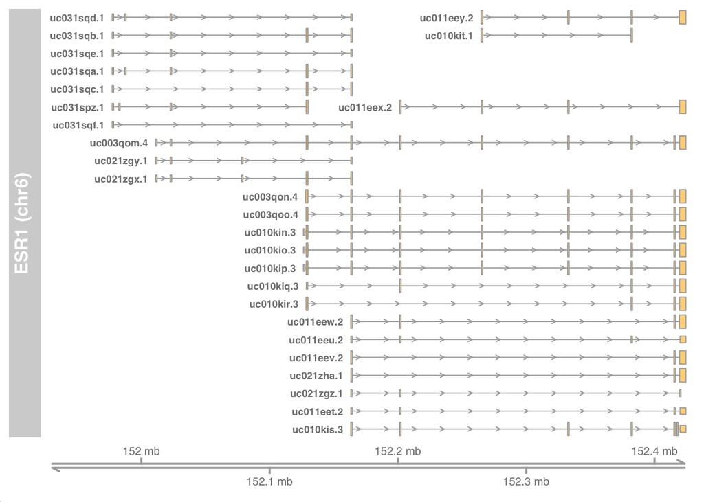

```r
stopifnot(packageVersion("ph525x") >= "0.0.16") # do over if fail

# The linear structures are transcripts, composed of untranslated regions at the ends, exons (small yellow rectangles), and introns (arrows between exons). The collection of transcripts makes up a "gene model".
modPlot("ESR1", useGeneSym=FALSE, collapse=FALSE)
```

```r
library(TxDb.Hsapiens.UCSC.hg19.knownGene)
txdb = TxDb.Hsapiens.UCSC.hg19.knownGene  # abbreviate

# gene_id = 2099

txs.2099 <- transcriptsBy(txdb, by="gene")$"2099"
length(txs.2099)
```

```
## [1] 27
```

## AnnotationHub, liftOver and rtracklayer

```r
# install.packages("remotes")

# remotes::install_version("dbplyr", version = "2.3.4")
# remotes::install_version("dplyr",  version = "1.1.2")
# remotes::install_version("DBI", version = "1.2.3")

library(AnnotationHub)
ah <- AnnotationHub()
```

```
## snapshotDate(): 2022-10-31
```

```r
ah
```

```
## AnnotationHub with 69797 records
## # snapshotDate(): 2022-10-31
## # $dataprovider: Ensembl, BroadInstitute, UCSC, ftp://ftp.ncbi.nlm.nih.gov/g...
## # $species: Homo sapiens, Mus musculus, Drosophila melanogaster, Bos taurus,...
## # $rdataclass: GRanges, TwoBitFile, BigWigFile, EnsDb, Rle, OrgDb, ChainFile...
## # additional mcols(): taxonomyid, genome, description,
## #   coordinate_1_based, maintainer, rdatadateadded, preparerclass, tags,
## #   rdatapath, sourceurl, sourcetype
## # retrieve records with, e.g., 'object[["AH5012"]]'
##
##
##   AH5012   |
##   AH5013   |
##   AH5014   |
##   AH5015   |
##   AH5016   |
##   ...
##   AH111329 |
##   AH111330 |
##   AH111331 |
##   AH111332 |
##   AH111334 |
##            title
##   AH5012   Chromosome Band
##   AH5013   STS Markers
##   AH5014   FISH Clones
##   AH5015   Recomb Rate
##   AH5016   ENCODE Pilot
##   ...      ...
##   AH111329 Zonotrichia_albicollis.Zonotrichia_albicollis-1.0.1.109.abinitio...
##   AH111330 Zonotrichia_albicollis.Zonotrichia_albicollis-1.0.1.109.gtf
##   AH111331 Zosterops_lateralis_melanops.ASM128173v1.109.abinitio.gtf
##   AH111332 Zosterops_lateralis_melanops.ASM128173v1.109.gtf
##   AH111334 MassBank CompDb for release 2022.12.1
```

```r
methods(class="AnnotationHub")
```

```
##  [1] [              [[             $              as.list        c
##  [6] cache          cache<-        coerce         dbconn         dbfile
## [11] display        fileName       hubCache       hubDate        hubUrl
## [16] isLocalHub     isLocalHub<-   length         mcols          names
## [21] package        query          recordStatus   show           snapshotDate
## [26] snapshotDate<- subset
## see '?methods' for accessing help and source code
```

```r
# lists the number of unique species which currently have records in AnnotationHub
length(unique(ah$species))
```

```
## [1] 2886
```

```r
# filters records that match specific fields
ah_human <- subset(ah, species == "Homo sapiens")
ah_human
```

```
## AnnotationHub with 26553 records
## # snapshotDate(): 2022-10-31
## # $dataprovider: BroadInstitute, UCSC, Ensembl, GENCODE, UWashington, Stanfo...
## # $species: Homo sapiens
## # $rdataclass: GRanges, BigWigFile, Rle, ChainFile, TwoBitFile, list, data.f...
## # additional mcols(): taxonomyid, genome, description,
## #   coordinate_1_based, maintainer, rdatadateadded, preparerclass, tags,
## #   rdatapath, sourceurl, sourcetype
## # retrieve records with, e.g., 'object[["AH5012"]]'
##
##              title
##   AH5012   | Chromosome Band
##   AH5013   | STS Markers
##   AH5014   | FISH Clones
##   AH5015   | Recomb Rate
##   AH5016   | ENCODE Pilot
##   ...        ...
##   AH107363 | hg19.UCSC.heterochromatin
##   AH107364 | hg19.UCSC.clone
##   AH107365 | hg19.UCSC.contig
##   AH109336 | Ensembl 108 EnsDb for Homo sapiens
##   AH109606 | Ensembl 109 EnsDb for Homo sapiens
```

```r
# searches for records that match a desired string in any of their fields. Unlike subset(), you do not need to specify which field to search.
query(ah, "HepG2")
```

```
## AnnotationHub with 440 records
## # snapshotDate(): 2022-10-31
## # $dataprovider: UCSC, BroadInstitute, Pazar
## # $species: Homo sapiens, NA
## # $rdataclass: GRanges, BigWigFile
## # additional mcols(): taxonomyid, genome, description,
## #   coordinate_1_based, maintainer, rdatadateadded, preparerclass, tags,
## #   rdatapath, sourceurl, sourcetype
## # retrieve records with, e.g., 'object[["AH22246"]]'
##
##             title
##   AH22246 | pazar_CEBPA_HEPG2_Schmidt_20120522.csv
##   AH22249 | pazar_CTCF_HEPG2_Schmidt_20120522.csv
##   AH22273 | pazar_HNF4A_HEPG2_Schmidt_20120522.csv
##   AH22309 | pazar_STAG1_HEPG2_Schmidt_20120522.csv
##   AH22348 | wgEncodeAffyRnaChipFiltTransfragsHepg2CytosolLongnonpolya.broadP...
##   ...       ...
##   AH41564 | E118-H4K5ac.imputed.pval.signal.bigwig
##   AH41691 | E118-H4K8ac.imputed.pval.signal.bigwig
##   AH41818 | E118-H4K91ac.imputed.pval.signal.bigwig
##   AH46971 | E118_15_coreMarks_mnemonics.bed.gz
##   AH49484 | E118_RRBS_FractionalMethylation.bigwig
```

```r
# multiple terms at once
query(ah, c("HepG2", "H3K4me3"))
```

```
## AnnotationHub with 11 records
## # snapshotDate(): 2022-10-31
## # $dataprovider: BroadInstitute, UCSC
## # $species: Homo sapiens
## # $rdataclass: GRanges, BigWigFile
## # additional mcols(): taxonomyid, genome, description,
## #   coordinate_1_based, maintainer, rdatadateadded, preparerclass, tags,
## #   rdatapath, sourceurl, sourcetype
## # retrieve records with, e.g., 'object[["AH23311"]]'
##
##             title
##   AH23311 | wgEncodeBroadHistoneHepg2H3k4me3StdPk.broadPeak.gz
##   AH27201 | wgEncodeUwHistoneHepg2H3k4me3StdHotspotsRep1.broadPeak.gz
##   AH27202 | wgEncodeUwHistoneHepg2H3k4me3StdHotspotsRep2.broadPeak.gz
##   AH27203 | wgEncodeUwHistoneHepg2H3k4me3StdPkRep1.narrowPeak.gz
##   AH27204 | wgEncodeUwHistoneHepg2H3k4me3StdPkRep2.narrowPeak.gz
##   ...       ...
##   AH30771 | E118-H3K4me3.narrowPeak.gz
##   AH31712 | E118-H3K4me3.gappedPeak.gz
##   AH32893 | E118-H3K4me3.fc.signal.bigwig
##   AH33925 | E118-H3K4me3.pval.signal.bigwig
##   AH40296 | E118-H3K4me3.imputed.pval.signal.bigwig
```

```r
hepg2 <- query(ah, "HepG2")
hepg2_h3k4me3 <- query(hepg2, c("H3K4me3"))
hepg2_h3k4me3
```

```
## AnnotationHub with 11 records
## # snapshotDate(): 2022-10-31
## # $dataprovider: BroadInstitute, UCSC
## # $species: Homo sapiens
## # $rdataclass: GRanges, BigWigFile
## # additional mcols(): taxonomyid, genome, description,
## #   coordinate_1_based, maintainer, rdatadateadded, preparerclass, tags,
## #   rdatapath, sourceurl, sourcetype
## # retrieve records with, e.g., 'object[["AH23311"]]'
##
##             title
##   AH23311 | wgEncodeBroadHistoneHepg2H3k4me3StdPk.broadPeak.gz
##   AH27201 | wgEncodeUwHistoneHepg2H3k4me3StdHotspotsRep1.broadPeak.gz
##   AH27202 | wgEncodeUwHistoneHepg2H3k4me3StdHotspotsRep2.broadPeak.gz
##   AH27203 | wgEncodeUwHistoneHepg2H3k4me3StdPkRep1.narrowPeak.gz
##   AH27204 | wgEncodeUwHistoneHepg2H3k4me3StdPkRep2.narrowPeak.gz
##   ...       ...
##   AH30771 | E118-H3K4me3.narrowPeak.gz
##   AH31712 | E118-H3K4me3.gappedPeak.gz
##   AH32893 | E118-H3K4me3.fc.signal.bigwig
##   AH33925 | E118-H3K4me3.pval.signal.bigwig
##   AH40296 | E118-H3K4me3.imputed.pval.signal.bigwig
```

```r
# annotation metadata
hepg2_h3k4me3$tags
```

```
##  [1] "wgEncode, ChipSeq, broadPeak, HepG2 cell, Bernstein grant"
##  [2] "wgEncode, ChipSeq, broadPeak, HepG2 cell, Stam grant"
##  [3] "wgEncode, ChipSeq, broadPeak, HepG2 cell, Stam grant"
##  [4] "wgEncode, ChipSeq, narrowPeak, HepG2 cell, Stam grant"
##  [5] "wgEncode, ChipSeq, narrowPeak, HepG2 cell, Stam grant"
##  [6] "EpigenomeRoadMap, peaks, consolidated, broadPeak, E118, ENCODE2012, LIV.HEPG2.CNCR, HepG2 Hepatocellular Carcinoma Cell Line"
##  [7] "EpigenomeRoadMap, peaks, consolidated, narrowPeak, E118, ENCODE2012, LIV.HEPG2.CNCR, HepG2 Hepatocellular Carcinoma Cell Line"
##  [8] "EpigenomeRoadMap, peaks, consolidated, gappedPeak, E118, ENCODE2012, LIV.HEPG2.CNCR, HepG2 Hepatocellular Carcinoma Cell Line"
##  [9] "EpigenomeRoadMap, signal, consolidated, macs2signal, E118, ENCODE2012, LIV.HEPG2.CNCR, HepG2 Hepatocellular Carcinoma Cell Line"
## [10] "EpigenomeRoadMap, signal, consolidated, macs2signal, E118, ENCODE2012, LIV.HEPG2.CNCR, HepG2 Hepatocellular Carcinoma Cell Line"
## [11] "EpigenomeRoadMap, signal, consolidatedImputed, H3K4me3, E118, ENCODE2012, LIV.HEPG2.CNCR, HepG2 Hepatocellular Carcinoma Cell Line"
```

```r
# # search records interactively by using display on a query
# display(query(ah, "HepG2"))

# To load a record from AnnotationHub, you need its ID. These commands find the ID number of the HepG2 H3K4me3 broadPeak file
e118_broadpeak <- query(hepg2_h3k4me3, c("E118", "broadPeak"))
id <- e118_broadpeak$ah_id
id
```

```
## [1] "AH29728"
```

```r
hepg2_h3k4me3_broad <- ah[["AH29728"]]
```

```
## loading from cache
```

```r
hepg2_h3k4me3_broad
```

```
## GRanges object with 60638 ranges and 5 metadata columns:
##           seqnames            ranges strand |        name     score signalValue
##              <Rle>         <IRanges>  <Rle> | <character> <numeric>   <numeric>
##       [1]    chr14 24614467-24618166      * |      Rank_1       850     20.3233
##       [2]    chr20   3183140-3185609      * |      Rank_2       830     25.7534
##       [3]    chr14 24700096-24704098      * |      Rank_3       811     17.2931
##       [4]    chr14 24766070-24770499      * |      Rank_4       763     18.9677
##       [5]    chr20 44420138-44421910      * |      Rank_5       755     24.0763
##       ...      ...               ...    ... .         ...       ...         ...
##   [60634]     chr2 11928736-11929617      * |  Rank_60634         0     1.73093
##   [60635]    chr10 97229724-97230412      * |  Rank_60635         0     1.73015
##   [60636]     chr2 39896310-39896946      * |  Rank_60636         0     1.73014
##   [60637]     chr6   3978391-3978677      * |  Rank_60637         0     1.73015
##   [60638]     chr6 49433554-49434110      * |  Rank_60638         0     1.73014
##              pValue    qValue
##           <numeric> <numeric>
##       [1]   88.3475   85.0287
##       [2]   86.2138   83.0301
##       [3]   84.3213   81.1706
##       [4]   79.3876   76.3449
##       [5]   78.6304   75.5947
##       ...       ...       ...
##   [60634]   1.00441         0
##   [60635]   1.00357         0
##   [60636]   1.00357         0
##   [60637]   1.00357         0
##   [60638]   1.00357         0
##   -------
##   seqinfo: 298 sequences (2 circular) from hg19 genome
```

```r
# store the ID as a variable and use that variable for indexing
alt_format <- ah[[id]]
```

```
## loading from cache
```

```r
identical(hepg2_h3k4me3_broad, alt_format)
```

```
## [1] TRUE
```

### Assessment

```r
library(AnnotationHub)
ah = AnnotationHub()
```

```
## snapshotDate(): 2022-10-31
```

```r
mah = mcols(ah)
names(mah)
```

```
##  [1] "title"              "dataprovider"       "species"
##  [4] "taxonomyid"         "genome"             "description"
##  [7] "coordinate_1_based" "maintainer"         "rdatadateadded"
## [10] "preparerclass"      "tags"               "rdataclass"
## [13] "rdatapath"          "sourceurl"          "sourcetype"
```

```r
sort(table(mah$species), decreasing=TRUE)[1:10]
```

```
##
##            Homo sapiens            Mus musculus Drosophila melanogaster
##                   26553                    1809                     459
##              Bos taurus       Rattus norvegicus         Pan troglodytes
##                     332                     326                     318
##             Danio rerio           Gallus gallus   Monodelphis domestica
##                     317                     285                     257
##  Caenorhabditis elegans
##                     246
```

```r
# files that address binding of CTCF to DNA from HepG2 cells
HepG2.CTCF = query(query(ah, "HepG2"), "CTCF")
HepG2.CTCF
```

```
## AnnotationHub with 13 records
## # snapshotDate(): 2022-10-31
## # $dataprovider: UCSC, Pazar
## # $species: Homo sapiens, NA
## # $rdataclass: GRanges
## # additional mcols(): taxonomyid, genome, description,
## #   coordinate_1_based, maintainer, rdatadateadded, preparerclass, tags,
## #   rdatapath, sourceurl, sourcetype
## # retrieve records with, e.g., 'object[["AH22249"]]'
##
##             title
##   AH22249 | pazar_CTCF_HEPG2_Schmidt_20120522.csv
##   AH22531 | wgEncodeAwgTfbsBroadHepg2CtcfUniPk.narrowPeak.gz
##   AH22693 | wgEncodeAwgTfbsHaibHepg2Ctcfsc5916V0416101UniPk.narrowPeak.gz
##   AH23134 | wgEncodeAwgTfbsUtaHepg2CtcfUniPk.narrowPeak.gz
##   AH23186 | wgEncodeAwgTfbsUwHepg2CtcfUniPk.narrowPeak.gz
##   ...       ...
##   AH25461 | wgEncodeOpenChromChipHepg2CtcfPk.narrowPeak.gz
##   AH27539 | wgEncodeUwTfbsHepg2CtcfStdHotspotsRep1.broadPeak.gz
##   AH27540 | wgEncodeUwTfbsHepg2CtcfStdHotspotsRep2.broadPeak.gz
##   AH27541 | wgEncodeUwTfbsHepg2CtcfStdPkRep1.narrowPeak.gz
##   AH27542 | wgEncodeUwTfbsHepg2CtcfStdPkRep2.narrowPeak.gz
```

## liftOver: Translating between reference builds

```r
# learn about liftOver from rtracklayer
library(rtracklayer)
?liftOver

# Suppose we want to convert chromosome 1 gene locations from hg38 to hg19
# get the GRanges for those genes from the TxDb for hg38
# chromosome 1 gene locations in hg38
library(TxDb.Hsapiens.UCSC.hg38.knownGene)
tx38 <- TxDb.Hsapiens.UCSC.hg38.knownGene
# restricts the TxDb to features on chromosome 1
seqlevels(tx38, pruning.mode="coarse") = "chr1"
# acquires the GRanges for chromosome 1 genes
g1_38 <- genes(tx38)

# download the hg38 to hg19 chain file
library(AnnotationHub)
ah <- AnnotationHub()
```

```
## snapshotDate(): 2022-10-31
```

```r
# chain file that specifies how features match across genome builds
# searches AnnotationHub for chain files that relate hg19 and hg38
ah.chain <- subset(ah, rdataclass == "ChainFile" & species == "Homo sapiens")
query(ah.chain, c("hg19", "hg38"))
```

```
## AnnotationHub with 4 records
## # snapshotDate(): 2022-10-31
## # $dataprovider: UCSC, NCBI
## # $species: Homo sapiens
## # $rdataclass: ChainFile
## # additional mcols(): taxonomyid, genome, description,
## #   coordinate_1_based, maintainer, rdatadateadded, preparerclass, tags,
## #   rdatapath, sourceurl, sourcetype
## # retrieve records with, e.g., 'object[["AH14108"]]'
##
##             title
##   AH14108 | hg38ToHg19.over.chain.gz
##   AH14150 | hg19ToHg38.over.chain.gz
##   AH78915 | Chain file for Homo sapiens rRNA hg19 to hg38
##   AH78916 | Chain file for Homo sapiens rRNA hg38 to hg19
```

```r
# choose the record titled hg38toHg19.over.chain.gz.
ch <- ah[["AH14108"]]
```

```
## loading from cache
```

```r
# perform the liftOver
# GRanges as the first argument and the chain file as the second argument
g1_19L <- liftOver(g1_38, ch)
g1_19L
```

```
## GRangesList object of length 3087:
## $`10000`
## GRanges object with 1 range and 1 metadata column:
##       seqnames              ranges strand |     gene_id
##          <Rle>           <IRanges>  <Rle> | <character>
##   [1]     chr1 243651535-244014381      - |       10000
##   -------
##   seqinfo: 18 sequences from an unspecified genome; no seqlengths
##
## $`100034743`
## GRanges object with 3 ranges and 1 metadata column:
##       seqnames              ranges strand |     gene_id
##          <Rle>           <IRanges>  <Rle> | <character>
##   [1]     chr1 147466094-147484530      - |   100034743
##   [2]     chr1 147484532-147484551      - |   100034743
##   [3]     chr1 147484553-147487188      - |   100034743
##   -------
##   seqinfo: 18 sequences from an unspecified genome; no seqlengths
##
## $`100126331`
## GRanges object with 1 range and 1 metadata column:
##       seqnames              ranges strand |     gene_id
##          <Rle>           <IRanges>  <Rle> | <character>
##   [1]     chr1 117637265-117637350      + |   100126331
##   -------
##   seqinfo: 18 sequences from an unspecified genome; no seqlengths
##
## ...
## <3084 more elements>
```

### Assessment

```r
# download.file("http://hgdownload.cse.ucsc.edu/goldenPath/hg19/liftOver/hg19ToHg38.over.chain.gz", "hg19ToHg38.over.chain.gz")
# library(R.utils)
# gunzip("hg19ToHg38.over.chain.gz")

library(ERBS)
data(HepG2)
library(rtracklayer)
# convert the HepG2 binding addresses to hg38
ch = import.chain("hg19ToHg38.over.chain")
nHepG2 = liftOver(HepG2, ch)
nHepG2
```

```
## GRangesList object of length 303:
## [[1]]
## GRanges object with 1 range and 7 metadata columns:
##       seqnames            ranges strand |      name     score       col
##          <Rle>         <IRanges>  <Rle> | <numeric> <integer> <logical>
##   [1]     chr2 20135617-20136026      * |        NA         0      <NA>
##       signalValue    pValue      qValue      peak
##         <numeric> <numeric>   <numeric> <integer>
##   [1]      58.251    75.899 6.14371e-72       195
##   -------
##   seqinfo: 23 sequences from an unspecified genome; no seqlengths
##
## [[2]]
## GRanges object with 1 range and 7 metadata columns:
##       seqnames        ranges strand |      name     score       col signalValue
##          <Rle>     <IRanges>  <Rle> | <numeric> <integer> <logical>   <numeric>
##   [1]    chr20 347641-348501      * |        NA         0      <NA>      10.808
##          pValue      qValue      peak
##       <numeric>   <numeric> <integer>
##   [1]    69.685 5.02806e-66       321
##   -------
##   seqinfo: 23 sequences from an unspecified genome; no seqlengths
##
## [[3]]
## GRanges object with 1 range and 7 metadata columns:
##       seqnames              ranges strand |      name     score       col
##          <Rle>           <IRanges>  <Rle> | <numeric> <integer> <logical>
##   [1]     chr6 167734752-167735907      * |        NA         0      <NA>
##       signalValue    pValue      qValue      peak
##         <numeric> <numeric>   <numeric> <integer>
##   [1]      17.103    54.311 7.93067e-51       930
##   -------
##   seqinfo: 23 sequences from an unspecified genome; no seqlengths
##
## ...
## <300 more elements>
```

```r
start(HepG2)[1] - start(nHepG2)[1]
```

```
## IntegerList of length 1
## [[1]] 199761
```

## Data import and export with rtracklayer

```r
library(devtools)
install_github("genomicsclass/ERBS")    # install ERBS package
```

```
## Skipping install of 'ERBS' from a github remote, the SHA1 (9f16eb6a) has not changed since last install.
##   Use `force = TRUE` to force installation
```

```r
# finds the path to the first file in the extdata directory of the ERBS package on your machine and assigns that file path to f1
# narrowPeak file containing ER binding data from ENCODE
f1 = dir(system.file("extdata",package="ERBS"), full=TRUE)[1]    # access data
# follows a similar format to BED files with 4 additional columns specific to narrowPeak data
# raw text that is tab-separated into columns
readLines(f1, 4)    # look at a few lines
```

```
## [1] "chrX\t1509354\t1512462\t5\t0\t.\t157.92\t310\t32.000000\t1991"
## [2] "chrX\t26801421\t26802448\t6\t0\t.\t147.38\t310\t32.000000\t387"
## [3] "chr19\t11694101\t11695359\t1\t0\t.\t99.71\t311.66\t32.000000\t861"
## [4] "chr19\t4076892\t4079276\t4\t0\t.\t84.74\t310\t32.000000\t1508"
```

```r
# input file and a format argument that specifies how to parse that file into an object
library(rtracklayer)
imp = import(f1, format="bedGraph")    # import as bedGraph format
# extra columns in the narrowPeak format are not named
# can add metadata column names with names(mcols(imp))
imp
```

```
## GRanges object with 1873 ranges and 7 metadata columns:
##          seqnames            ranges strand |     score       NA.     NA..1
##             <Rle>         <IRanges>  <Rle> | <numeric> <integer> <logical>
##      [1]     chrX   1509355-1512462      * |         5         0      <NA>
##      [2]     chrX 26801422-26802448      * |         6         0      <NA>
##      [3]    chr19 11694102-11695359      * |         1         0      <NA>
##      [4]    chr19   4076893-4079276      * |         4         0      <NA>
##      [5]     chr3 53288568-53290767      * |         9         0      <NA>
##      ...      ...               ...    ... .       ...       ...       ...
##   [1869]    chr19 11201120-11203985      * |      8701         0      <NA>
##   [1870]    chr19   2234920-2237370      * |       990         0      <NA>
##   [1871]     chr1 94311336-94313543      * |      4035         0      <NA>
##   [1872]    chr19 45690614-45691210      * |     10688         0      <NA>
##   [1873]    chr19   6110100-6111252      * |      2274         0      <NA>
##              NA..2     NA..3     NA..4     NA..5
##          <numeric> <numeric> <numeric> <integer>
##      [1]    157.92   310.000        32      1991
##      [2]    147.38   310.000        32       387
##      [3]     99.71   311.660        32       861
##      [4]     84.74   310.000        32      1508
##      [5]     78.20   299.505        32      1772
##      ...       ...       ...       ...       ...
##   [1869]      8.65     7.281   0.26576      2496
##   [1870]      8.65    26.258   1.99568      1478
##   [1871]      8.65    12.511   1.47237      1848
##   [1872]      8.65     6.205   0.00000       298
##   [1873]      8.65    17.356   2.01323       496
##   -------
##   seqinfo: 23 sequences from an unspecified genome; no seqlengths
```

```r
# set genome explicitly to ensure your data is processed correctly downstream
# genome of the GRanges is NA by default
genome(imp)    # genome identifier tag not set, but you should set it
```

```
##  chrX chr19  chr3 chr17  chr8 chr11 chr16  chr1  chr2  chr6  chr9  chr7  chr5
##    NA    NA    NA    NA    NA    NA    NA    NA    NA    NA    NA    NA    NA
## chr12 chr20 chr21 chr22 chr18 chr10 chr14 chr15  chr4 chr13
##    NA    NA    NA    NA    NA    NA    NA    NA    NA    NA
```

```r
genome(imp) = "hg19"    # set genome
genome(imp)
```

```
##   chrX  chr19   chr3  chr17   chr8  chr11  chr16   chr1   chr2   chr6   chr9
## "hg19" "hg19" "hg19" "hg19" "hg19" "hg19" "hg19" "hg19" "hg19" "hg19" "hg19"
##   chr7   chr5  chr12  chr20  chr21  chr22  chr18  chr10  chr14  chr15   chr4
## "hg19" "hg19" "hg19" "hg19" "hg19" "hg19" "hg19" "hg19" "hg19" "hg19" "hg19"
##  chr13
## "hg19"
```

```r
# export() takes an object and writes an output file in a common genomic file format
# GRanges gets converted into a BED format file
export(imp, "demoex.bed")    # export as BED format
cat(readLines("demoex.bed", n=5), sep="\n")    # check output file
```

```
## chrX 1509354 1512462 .   5   .
## chrX 26801421    26802448    .   6   .
## chr19    11694101    11695359    .   1   .
## chr19    4076892 4079276 .   4   .
## chr3 53288567    53290767    .   9   .
```

```r
library(rtracklayer)
data(targets) # microRNA target sites

# It is not typical to add metadata to data.frame instances, as one has to fill a column with relevant information -> no reference genome information available in targets
class(targets)
```

```
## [1] "data.frame"
```

```r
summary(targets)
```

```
##            name                  target        chrom
##  hsa-miR-144 : 100   ENST00000000412:   1   Length:2981
##  hsa-miR-106b:  78   ENST00000003084:   1   Class :character
##  hsa-miR-10a*:  77   ENST00000003834:   1   Mode  :character
##  hsa-miR-125b:  64   ENST00000006015:   1
##  hsa-miR-148a:  64   ENST00000006101:   1
##  hsa-miR-19a :  64   ENST00000006658:   1
##  (Other)     :2534   (Other)        :2975
##      start                end            strand
##  Min.   :   200192   Min.   :   200213   -:1583
##  1st Qu.: 36330512   1st Qu.: 36330536   +:1398
##  Median : 71891755   Median : 71891776
##  Mean   : 81956260   Mean   : 81956285
##  3rd Qu.:119449069   3rd Qu.:119449090
##  Max.   :245386472   Max.   :245386490
##
```

```r
targets
```

```
##                    name          target chrom     start       end strand
## 555774       hsa-miR-16 ENST00000000412 chr12   8985197   8985217      -
## 415091   hsa-miR-509-3p ENST00000003084  chr7 117095440 117095461      +
## 594550      hsa-miR-612 ENST00000003834 chr17  23750064  23750088      +
## 398678   hsa-miR-423-3p ENST00000006015  chr7  27187935  27187957      -
## 607152     hsa-miR-125b ENST00000006101 chr17  43458623  43458643      -
## 608640   hsa-miR-324-3p ENST00000006658 chr17  45988032  45988051      +
## 608183      hsa-miR-150 ENST00000007722 chr17  45522397  45522418      +
## 117771      hsa-miR-558 ENST00000008180 chr16   3059465   3059483      +
## 553079      hsa-miR-144 ENST00000010132 chr12   4593228   4593247      +
## 313594      hsa-miR-454 ENST00000012134  chr6 143115523 143115545      -
## 399301     hsa-miR-363* ENST00000013222  chr7  30762773  30762794      +
## 174056     hsa-miR-196b ENST00000013807 chr19  50608607  50608628      -
## 557351     hsa-miR-125b ENST00000014914 chr12  12956981  12957002      +
## 557397   hsa-miR-139-3p ENST00000014930 chr12  13019461  13019485      -
```

[output cut: 2967 more lines]

```r
library(GenomicRanges)
mtar <- with(targets,
GRanges(chrom, IRanges(start,end), strand=strand,
targets=target, mirname=name))

cat(export(mtar[1:5], format="bed"), sep="\n")
```

```
## chr12    8985196 8985217 .   0   -
## chr7 117095439   117095461   .   0   +
## chr17    23750063    23750088    .   0   +
## chr7 27187934    27187957    .   0   -
## chr17    43458622    43458643    .   0   -
```

```r
cat("\n")
```

```r
cat(export(mtar[1:5], format="gff3"), sep="\n")
```

```
## ##gff-version 3
## ##source-version rtracklayer 1.58.0
## ##date 2026-03-05
## chr12    rtracklayer sequence_feature    8985197 8985217 .   -   .   targets=ENST00000000412;mirname=hsa-miR-16
## chr7 rtracklayer sequence_feature    117095440   117095461   .   +   .   targets=ENST00000003084;mirname=hsa-miR-509-3p
## chr17    rtracklayer sequence_feature    23750064    23750088    .   +   .   targets=ENST00000003834;mirname=hsa-miR-612
## chr7 rtracklayer sequence_feature    27187935    27187957    .   -   .   targets=ENST00000006015;mirname=hsa-miR-423-3p
## chr17    rtracklayer sequence_feature    43458623    43458643    .   -   .   targets=ENST00000006101;mirname=hsa-miR-125b
```

```r
mtar[1]$mirname # name of microRNA
```

```
## [1] hsa-miR-16
## 694 Levels: hsa-miR-1 hsa-miR-100 hsa-miR-100* hsa-miR-101 ... hsa-miR-99b*
```

```r
# OR in GFF3 format
```

# Annotation tools for systems biology

## OrgDb: unified organism-specific annotation for systems biology

Packages named org.*.eg.db collect information at the gene level with links to location, protein product identifiers, KEGG pathway and GO terms, PMIDs of papers mentioning genes, and to identifiers for other annotation resources.

```r
# load human OrgDb and inspect available keys
# org: organism level annotation
# Hs: Homo Sapiens
# eg: Entrez gene as resource
# db: SQLite based package
library(org.Hs.eg.db)
org.Hs.eg.db
```

```
## OrgDb object:
## | DBSCHEMAVERSION: 2.1
## | Db type: OrgDb
## | Supporting package: AnnotationDbi
## | DBSCHEMA: HUMAN_DB
## | ORGANISM: Homo sapiens
## | SPECIES: Human
## | EGSOURCEDATE: 2022-Sep12
## | EGSOURCENAME: Entrez Gene
## | EGSOURCEURL: ftp://ftp.ncbi.nlm.nih.gov/gene/DATA
## | CENTRALID: EG
## | TAXID: 9606
## | GOSOURCENAME: Gene Ontology
## | GOSOURCEURL: http://current.geneontology.org/ontology/go-basic.obo
## | GOSOURCEDATE: 2022-07-01
## | GOEGSOURCEDATE: 2022-Sep12
## | GOEGSOURCENAME: Entrez Gene
## | GOEGSOURCEURL: ftp://ftp.ncbi.nlm.nih.gov/gene/DATA
## | KEGGSOURCENAME: KEGG GENOME
## | KEGGSOURCEURL: ftp://ftp.genome.jp/pub/kegg/genomes
## | KEGGSOURCEDATE: 2011-Mar15
## | GPSOURCENAME: UCSC Genome Bioinformatics (Homo sapiens)
## | GPSOURCEURL:
## | GPSOURCEDATE: 2022-Aug31
## | ENSOURCEDATE: 2022-Jun28
## | ENSOURCENAME: Ensembl
## | ENSOURCEURL: ftp://ftp.ensembl.org/pub/current_fasta
## | UPSOURCENAME: Uniprot
## | UPSOURCEURL: http://www.UniProt.org/
## | UPSOURCEDATE: Fri Sep 23 16:26:35 2022
```

```
##
## Please see: help('select') for usage information
```

```r
keytypes(org.Hs.eg.db) # columns() gives same answer
```

```
##  [1] "ACCNUM"       "ALIAS"        "ENSEMBL"      "ENSEMBLPROT"  "ENSEMBLTRANS"
##  [6] "ENTREZID"     "ENZYME"       "EVIDENCE"     "EVIDENCEALL"  "GENENAME"
## [11] "GENETYPE"     "GO"           "GOALL"        "IPI"          "MAP"
## [16] "OMIM"         "ONTOLOGY"     "ONTOLOGYALL"  "PATH"         "PFAM"
## [21] "PMID"         "PROSITE"      "REFSEQ"       "SYMBOL"       "UCSCKG"
## [26] "UNIPROT"
```

```r
# load GO.db and inspect available terms
library(GO.db)
allterms = keys(GO.db, keytype="TERM")
allterms[1:5]
```

```
## [1] "mitochondrion inheritance"
## [2] "mitochondrial genome maintenance"
## [3] "reproduction"
## [4] "high-affinity zinc transmembrane transporter activity"
## [5] "low-affinity zinc ion transmembrane transporter activity"
```

```r
# find GOID (gene ontology tag) for ribosome biogenesis
select(GO.db,  keys = "ribosome biogenesis", keytype="TERM", columns="GOID")
```

```
##                  TERM       GOID
## 1 ribosome biogenesis GO:0042254
```

```r
# find symbols for genes involved in ribosome biogenesis
select(org.Hs.eg.db, keys = "GO:0042254", keytype="GO", columns="SYMBOL")
```

```
##            GO EVIDENCE ONTOLOGY  SYMBOL
## 1  GO:0042254      ISS       BP    BYSL
## 2  GO:0042254      IMP       BP    GLUL
## 3  GO:0042254      IBA       BP     NVL
## 4  GO:0042254      IMP       BP     NVL
## 5  GO:0042254      IMP       BP   RPS28
## 6  GO:0042254      IMP       BP    XPO1
## 7  GO:0042254      IMP       BP   CUL4B
## 8  GO:0042254      IMP       BP   CUL4A
## 9  GO:0042254      IBA       BP    URB2
## 10 GO:0042254      IEA       BP MYBBP1A
## 11 GO:0042254       IC       BP    BOP1
## 12 GO:0042254      NAS       BP    BOP1
## 13 GO:0042254      IMP       BP  ZNF658
## 14 GO:0042254      IEA       BP    MTG2
```

[output cut: 17 more lines]

```r
# you can pull out multiple columns at once
select(org.Hs.eg.db, keys = "GO:0042254", keytype="GO", columns=c("SYMBOL", "ENTREZID"))
```

```
##            GO EVIDENCE ONTOLOGY  SYMBOL ENTREZID
## 1  GO:0042254      ISS       BP    BYSL      705
## 2  GO:0042254      IMP       BP    GLUL     2752
## 3  GO:0042254      IBA       BP     NVL     4931
## 4  GO:0042254      IMP       BP     NVL     4931
## 5  GO:0042254      IMP       BP   RPS28     6234
## 6  GO:0042254      IMP       BP    XPO1     7514
## 7  GO:0042254      IMP       BP   CUL4B     8450
## 8  GO:0042254      IMP       BP   CUL4A     8451
## 9  GO:0042254      IBA       BP    URB2     9816
## 10 GO:0042254      IEA       BP MYBBP1A    10514
## 11 GO:0042254       IC       BP    BOP1    23246
## 12 GO:0042254      NAS       BP    BOP1    23246
## 13 GO:0042254      IMP       BP  ZNF658    26149
## 14 GO:0042254      IEA       BP    MTG2    26164
```

[output cut: 17 more lines]

```r
# find gene ontology tags for related to ZNF658, which has the specified ENTREZID
select(org.Hs.eg.db, keys= "26149", keytype="ENTREZID", columns="GO")
```

```
##    ENTREZID         GO EVIDENCE ONTOLOGY
## 1     26149 GO:0000976      IDA       MF
## 2     26149 GO:0000978      IBA       MF
## 3     26149 GO:0001228      IBA       MF
## 4     26149 GO:0005634      IBA       CC
## 5     26149 GO:0006357      IBA       BP
## 6     26149 GO:0042254      IMP       BP
## 7     26149 GO:0045892      IMP       BP
## 8     26149 GO:0045944      IEA       BP
## 9     26149 GO:0046872      IEA       MF
## 10    26149 GO:0071294      IMP       BP
```

```r
# save GO tags to a character vector
select(org.Hs.eg.db, keys= "26149", keytype="ENTREZID", columns="GO")$"GO"
```

```
##  [1] "GO:0000976" "GO:0000978" "GO:0001228" "GO:0005634" "GO:0006357"
##  [6] "GO:0042254" "GO:0045892" "GO:0045944" "GO:0046872" "GO:0071294"
```

```r
# myk = .Last.value

# FOR KNIT purpose
# find GO tags related to ZNF658 (ENTREZID 26149)
go_tags <- select(org.Hs.eg.db,
                  keys = "26149",
                  keytype = "ENTREZID",
                  columns = "GO")
myk <- unique(na.omit(as.character(go_tags$GO)))

# identify biological processes ZNF658 is involved in
select(GO.db, keys=myk, columns="TERM")
```

```
##          GOID
## 1  GO:0000976
## 2  GO:0000978
## 3  GO:0001228
## 4  GO:0005634
## 5  GO:0006357
## 6  GO:0042254
## 7  GO:0045892
## 8  GO:0045944
## 9  GO:0046872
## 10 GO:0071294
##                                                                        TERM
## 1                               transcription cis-regulatory region binding
## 2     RNA polymerase II cis-regulatory region sequence-specific DNA binding
## 3  DNA-binding transcription activator activity, RNA polymerase II-specific
## 4                                                                   nucleus
## 5                          regulation of transcription by RNA polymerase II
## 6                                                       ribosome biogenesis
## 7                        negative regulation of DNA-templated transcription
## 8                 positive regulation of transcription by RNA polymerase II
## 9                                                         metal ion binding
## 10                                            cellular response to zinc ion
```

### Assessment

```r
genes_17q21 <- select(org.Hs.eg.db,
                       keys = "17q21.1",
                       columns = "SYMBOL",
                       keytype = "MAP")
length(genes_17q21$SYMBOL)
```

```
## [1] 21
```

```r
m17 = select(org.Hs.eg.db, keys="17q21.1", keytype="MAP", columns=c("SYMBOL", "GO"))
sort(table(m17$GO), decreasing=TRUE)[1:10]
```

```
##
## GO:0005515 GO:0005634 GO:0005654 GO:0000122 GO:0000978 GO:0005576 GO:0005829
##          9          7          7          4          4          4          4
## GO:0005886 GO:0016021 GO:0000785
##          4          4          3
```

```r
m17[m17$SYMBOL == "ORMDL3" & m17$EVIDENCE == "TAS", ]
```

```
##         MAP SYMBOL         GO EVIDENCE ONTOLOGY
## 240 17q21.1 ORMDL3 GO:0005886      TAS       CC
## 248 17q21.1 ORMDL3 GO:0030667      TAS       CC
## 251 17q21.1 ORMDL3 GO:0035579      TAS       CC
```

### Assessment

```r
library(Homo.sapiens)
g = genes(Homo.sapiens)
```

```
##   403 genes were dropped because they have exons located on both strands
##   of the same reference sequence or on more than one reference sequence,
##   so cannot be represented by a single genomic range.
##   Use 'single.strand.genes.only=FALSE' to get all the genes in a
##   GRangesList object, or use suppressMessages() to suppress this message.
```

```r
library(ERBS)
data(HepG2)

# resize(g,1) is a strand-respecting reduction of the gene interval to a single base representing the transcription start site
kp = g[resize(g,1) %over% HepG2]

nn = names(kp)
m = select(Homo.sapiens, keys=nn, keytype="ENTREZID",
           columns=c("SYMBOL", "GENENAME", "TERM", "GO"))
library(DT)
datatable(m)
```

|  | ENTREZID | GO | GENENAME | EVIDENCE | ONTOLOGY | SYMBOL | TERM |
| --- | --- | --- | --- | --- | --- | --- | --- |
| 1 | 100129518 |  | SOD2 overlapping transcript 1 |  |  | SOD2-OT1 |  |
| 2 | 100134015 |  | UBOX5 antisense RNA 1 |  |  | UBOX5-AS1 |  |
| 3 | 10116 | GO:0005123 | fem-1 homolog B | NAS | MF | FEM1B | death receptor binding |
| 4 | 10116 | GO:0005123 | fem-1 homolog B | IMP | MF | FEM1B | death receptor binding |
| 5 | 10116 | GO:0005515 | fem-1 homolog B | IPI | MF | FEM1B | protein binding |
| 6 | 10116 | GO:0005634 | fem-1 homolog B | IDA | CC | FEM1B | nucleus |
| 7 | 10116 | GO:0005634 | fem-1 homolog B | IBA | CC | FEM1B | nucleus |
| 8 | 10116 | GO:0005654 | fem-1 homolog B | IDA | CC | FEM1B | nucleoplasm |
| 9 | 10116 | GO:0005737 | fem-1 homolog B | IDA | CC | FEM1B | cytoplasm |
| 10 | 10116 | GO:0005829 | fem-1 homolog B | TAS | CC | FEM1B | cytosol |

[output cut: 1339 more lines]

## Using Kyoto Encyclopedia of Genes and Genomes (KEGG)

```r
# load KEGGREST package and inspect organism-specific gene pathways
library(KEGGREST)
brca2K = keggGet("hsa:675")    # reference to a specific gene
names(brca2K[[1]])
```

```
##  [1] "ENTRY"     "SYMBOL"    "NAME"      "ORTHOLOGY" "ORGANISM"  "PATHWAY"
##  [7] "NETWORK"   "DISEASE"   "BRITE"     "POSITION"  "MOTIF"     "DBLINKS"
## [13] "STRUCTURE" "AASEQ"     "NTSEQ"
```

```r
brpat = keggGet("path:hsa05212")    # info on a pathway
brpat[[1]]$GENE[seq(1,132,2)] # entrez gene ids for pathway
```

```
##  [1] "10000"     "1019"      "1021"      "1026"      "1029"      "10912"
##  [7] "10928"     "110117499" "1147"      "1643"      "1647"      "1869"
## [13] "1870"      "1871"      "1950"      "1956"      "2064"      "207"
## [19] "208"       "2475"      "3551"      "369"       "3716"      "3845"
## [25] "4087"      "4088"      "4089"      "4616"      "4790"      "51426"
## [31] "5290"      "5291"      "5293"      "5295"      "5296"      "5337"
## [37] "5338"      "5594"      "5595"      "5599"      "5601"      "5602"
## [43] "5604"      "572"       "578"       "581"       "5879"      "5880"
## [49] "5881"      "5888"      "5894"      "5898"      "5899"      "5900"
## [55] "5925"      "595"       "5970"      "598"       "6198"      "6199"
## [61] "673"       "675"       "6772"      "6774"      "7039"      "7040"
```

```r
# inspect some entrez ids
select(org.Hs.eg.db, keys="5888", keytype="ENTREZID", columns ="SYMBOL")
```

```
##   ENTREZID SYMBOL
## 1     5888  RAD51
```

```r
select(org.Hs.eg.db, keys="675", keytype="ENTREZID", columns ="SYMBOL")
```

```
##   ENTREZID SYMBOL
## 1      675  BRCA2
```

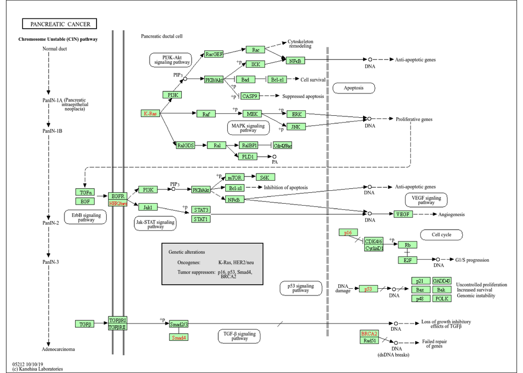

```r
# diagram showing structure of network
library(png)
library(grid)
brpng = keggGet("hsa05212", "image")
grid.newpage()
grid.raster(brpng)
```

```r
# # working one
# url <- "https://rest.kegg.jp/get/hsa05212/image"
# tmp <- tempfile(fileext = ".png")
#
# download.file(url, tmp, mode = "wb", quiet = TRUE)
#
# img <- png::readPNG(tmp)
# grid::grid.newpage()
# grid::grid.raster(img)
#
# # working one 2
# brpng <- keggGet("hsa05212", "image")
#
# img <- if (is.list(brpng)) brpng[[1]] else brpng   # handle both behaviors
#
# dim(img)        # should be 3 numbers, e.g. 925 1265 4
# range(img)      # should NOT be 0 0
#
# grid.newpage()
# grid.rect(gp = gpar(fill = "white", col = NA))
# grid.raster(img)
```

### Assessment

```r
hsa_3845 <- unlist(keggGet("hsa:3845"))
hsa_3845$NAME
```

```
## [1] "(RefSeq) GTPase KRas isoform a"
```

```r
length(keggGet("hsa:3845")[[1]]$PATHWAY)
```

```
## [1] 84
```

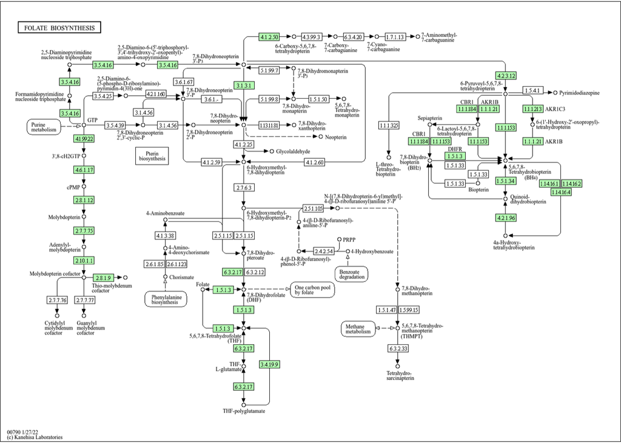

```r
library(png)
oo = keggGet("hsa00790", "image")
writePNG(oo, "im.png")
grid.newpage()
grid.raster(oo)
```

## EMBL’s ontology lookup service

```r
library(rols)
oo = Ontologies()
oo
```

```
## Object of class 'Ontologies' with 275 entries
##    ADO, AfPO ... hgnc.genegroup, PREFER
```

```r
oo[[1]]
```

```
## Ontology: Alzheimer's Disease Ontology (ADO) (ado)
##   Alzheimer's Disease Ontology is a knowledge-based ontology that
##   encompasses varieties of concepts related to Alzheimer'S Disease,
##   foundamentally structured by upper level Basic Formal Ontology(BFO).
##   This Ontology is enriched by the interrelational entities that
##   demonstrate the nextwork of the understanding on Alzheimer's disease
##   and can be readily applied for text mining.
##    Loaded: 2026-03-01 Updated: 2026-03-01 Version: 2.0.1
##    1963 terms  186 properties  2 individuals
```

```r
glis = OlsSearch("glioblastoma")
glis
```

```
## Object of class 'OlsSearch':
##   query: glioblastoma
##   requested: 20 (out of 632)
##   response(s): 0
```

```r
res = olsSearch(glis)
resdf = as(res, "data.frame") # get content
resdf[1:4,1:4]
```

```
##                                           iri ontology_name ontology_prefix
## 1   http://purl.obolibrary.org/obo/NCIT_C3058          ncit            NCIT
## 2    http://purl.obolibrary.org/obo/DOID_3068          doid            DOID
## 3    http://purl.obolibrary.org/obo/MPATH_564         mpath           MPATH
## 4 http://purl.obolibrary.org/obo/OMIT_0007102          omit            OMIT
##     short_form
## 1   NCIT_C3058
## 2    DOID_3068
## 3    MPATH_564
## 4 OMIT_0007102
```

```r
resdf[1,5]  # full description for one instance
```

```
## [[1]]
## [1] "The most malignant astrocytic tumor (WHO grade 4).  It is composed of poorly differentiated neoplastic astrocytes and is characterized by the presence of cellular polymorphism, nuclear atypia, brisk mitotic activity, vascular thrombosis, microvascular proliferation, and necrosis. It typicall…
```

### Assessment

```r
library(rols)
diab = OlsSearch("diabetes")
olsRows(allRows(diab))
```

```
## [1] 9800
```

```r
fulld = olsSearch(allRows(diab))
adf = as(fulld, "data.frame")
sort(table(adf$ontology_name), decreasing=TRUE)[1:10]
```

```
##
## snomed   ncit  mondo   mesh   doid    efo     hp    ror    cmo    oae
##    494    349     49     43     29      7      7      5      3      3
```

```r
library(DT)
datatable(adf)
```

|  | iri | ontology_name | ontology_prefix | short_form | description | label | obo_id | type | exact_synonyms | related_synonyms | narrow_synonyms | broad_synonyms |
| --- | --- | --- | --- | --- | --- | --- | --- | --- | --- | --- | --- | --- |
| 1 | http://purl.obolibrary.org/obo/DOID_9351 | doid | DOID | DOID_9351 | ['A glucose metabolism disease that is characterized by chronic hyperglycaemia with disturbances of carbohydrate, fat and protein metabolism resulting from defects in insulin secretion, insulin action… | diabetes mellitus | DOID:9351 | class | ['diabetes'] |  |  |  |
| 2 | http://purl.obolibrary.org/obo/NCIT_C212592 | ncit | NCIT | NCIT_C212592 | ['The service type that is associated with the Health Level 7 Fast Healthcare Interoperability Resources Diabetes code.'] | Diabetes Service Type | NCIT:C212592 | class | ['Diabetes', 'Diabetes Service Type'] |  |  |  |
| 3 | http://purl.obolibrary.org/obo/NCIT_C2985 | ncit | NCIT | NCIT_C2985 | ['A metabolic disorder characterized by abnormally high blood sugar levels due to diminished production of insulin or insulin resistance/desensitization.'] | Diabetes Mellitus | NCIT:C2985 | class | ['DM', 'Diabetes', 'Diabetes Mellitus', 'Diabetes mellitus', 'diabetes', 'diabetes mellitus'] |  |  |  |
| 4 | http://purl.obolibrary.org/obo/DOID_9351 | bmont | BMONT | DOID_9351 | ['A glucose metabolism disease that is characterized by chronic hyperglycaemia with disturbances of carbohydrate, fat and protein metabolism resulting from defects in insulin secretion, insulin action… | diabetes mellitus | DOID:9351 | class | ['diabetes'] |  |  |  |
| 5 | http://purl.obolibrary.org/obo/DOID_9351 | exmo | EXMO | DOID_9351 | ['A glucose metabolism disease that is characterized by chronic hyperglycaemia with disturbances of carbohydrate, fat and protein metabolism resulting from defects in insulin secretion, insulin action… | diabetes mellitus | DOID:9351 | class | ['diabetes'] |  |  |  |
| 6 | http://purl.obolibrary.org/obo/DOID_9351 | vo | VO | DOID_9351 | ['A glucose metabolism disease that is characterized by chronic hyperglycaemia with disturbances of carbohydrate, fat and protein metabolism resulting from defects in insulin secretion, insulin action… | diabetes mellitus | DOID:9351 | class | ['diabetes'] |  |  |  |
| 7 | http://purl.obolibrary.org/obo/MONDO_0005015 | mondo | MONDO | MONDO_0005015 | ['A metabolic disorder characterized by abnormally high blood sugar levels due to diminished production of insulin or insulin resistance/desensitization.'] | diabetes mellitus | MONDO:0005015 | class | ['DM', 'diabetes', 'diabetes mellitus', 'diabetes mellitus (disease)'] |  |  |  |
| 8 | http://www.ebi.ac.uk/efo/EFO_0000400 | efo | EFO | EFO_0000400 | ['A metabolic disorder characterized by abnormally high blood sugar levels due to diminished production of insulin or insulin resistance/desensitization.'] | diabetes mellitus | EFO:0000400 | class | ['DM', 'DM - Diabetes mellitus', 'Diabetes', 'Diabetes NOS', 'Diabetes mellitus (disorder)', 'Diabetes mellitus, NOS', 'diabetes', 'diabetes mellitus', 'diabetes mellitus (disease)'] |  |  |  |
| 9 | http://purl.obolibrary.org/obo/MONDO_0005015 | ado | ADO | MONDO_0005015 | ['A metabolic disorder characterized by abnormally high blood sugar levels due to diminished production of insulin or insulin resistance/desensitization.'] | diabetes mellitus (disease) | MONDO:0005015 | class | ['DM', 'diabetes', 'diabetes mellitus'] |  |  |  |
| 10 | http://www.ebi.ac.uk/efo/EFO_0000400 | pride | PRIDE | EFO_0000400 | ['A metabolic disorder characterized by abnormally high blood sugar levels due to diminished production of insulin or insulin resistance/desensitization.'] | diabetes mellitus | EFO:0000400 | class | ['DM', 'DM - Diabetes mellitus', 'Diabetes', 'Diabetes NOS', 'Diabetes mellitus (disorder)', 'Diabetes mellitus, NOS', 'diabetes', 'diabetes mellitus', 'diabetes mellitus (disease)'] |  |  |  |

[output cut: 990 more lines]

# Verified assessment

```r
library(BSgenome.Hsapiens.UCSC.hg19)
library(TxDb.Hsapiens.UCSC.hg19.knownGene)
library(org.Hs.eg.db)
library(ensembldb)
library(EnsDb.Hsapiens.v75)
library(GO.db)
library(AnnotationHub)
library(rtracklayer)
library(KEGGREST)

library(BSgenome.Hsapiens.UCSC.hg19)
Hsapiens
```

```
## Human genome:
## # organism: Homo sapiens (Human)
## # genome: hg19
## # provider: UCSC
## # release date: June 2013
## # 298 sequences:
## #   chr1                  chr2                  chr3
## #   chr4                  chr5                  chr6
## #   chr7                  chr8                  chr9
## #   chr10                 chr11                 chr12
## #   chr13                 chr14                 chr15
## #   ...                   ...                   ...
## #   chr19_gl949749_alt    chr19_gl949750_alt    chr19_gl949751_alt
## #   chr19_gl949752_alt    chr19_gl949753_alt    chr20_gl383577_alt
## #   chr21_gl383578_alt    chr21_gl383579_alt    chr21_gl383580_alt
## #   chr21_gl383581_alt    chr22_gl383582_alt    chr22_gl383583_alt
## #   chr22_kb663609_alt
## # (use 'seqnames()' to see all the sequence names, use the '$' or '[[' operator
## # to access a given sequence)
```

```r
sort(seqlengths(Hsapiens),decreasing=TRUE)
```

```
##                  chr1                  chr2                  chr3
##             249250621             243199373             198022430
##                  chr4                  chr5                  chr6
##             191154276             180915260             171115067
##                  chr7                  chrX                  chr8
##             159138663             155270560             146364022
##                  chr9                 chr10                 chr11
##             141213431             135534747             135006516
##                 chr12                 chr13                 chr14
##             133851895             115169878             107349540
##                 chr15                 chr16                 chr17
##             102531392              90354753              81195210
##                 chr18                 chr20                  chrY
##              78077248              63025520              59373566
##                 chr19                 chr22                 chr21
##              59128983              51304566              48129895
##     chr1_jh636052_fix     chrX_jh806600_fix        chr6_ssto_hap7
##               7283150               6530008               4928567
##         chr6_mcf_hap5         chr6_cox_hap2        chr6_mann_hap4
##               4833398               4795371               4683263
##         chr6_apd_hap1         chr6_qbl_hap6         chr6_dbb_hap3
##               4622290               4611984               4610396
##     chrX_jh806587_fix     chr7_jh159134_fix     chrX_jh159150_fix
##               4110759               3821770               3110903
##     chrX_jh806590_fix    chr10_jh591181_fix       chr17_ctg5_hap1
##               2418393               2281126               1680828
##     chr1_jh636053_fix     chr5_gl339449_alt    chr14_kb021645_fix
##               1676126               1612928               1523386
##     chrX_jh720453_fix     chrX_jh806601_fix     chr7_gl582971_fix
##               1461188               1389764               1284284
##     chrX_jh806599_fix    chr19_gl949749_alt    chr19_gl949750_alt
##               1214327               1091840               1066389
##    chr19_gl949748_alt    chr19_kb021647_fix     chrX_jh806597_fix
##               1064303               1058686               1045622
##    chr10_ke332501_fix    chr19_gl949751_alt    chr19_gl949746_alt
##               1020827               1002682                987716
##    chr19_gl949752_alt     chrX_jh806598_fix     chrX_jh720451_fix
##                987100                899320                898979
##     chrX_jh806591_fix    chr11_jh806581_fix     chrX_jh806588_fix
##                882083                872115                862483
```

[output cut: 145 more lines]

```
##                 39786                 38914                 38502
##        chrUn_gl000246 chr17_gl000203_random  chr8_gl000197_random
##                 38154                 37498                 37175
##        chrUn_gl000245        chrUn_gl000247  chr9_gl000201_random
##                 36651                 36422                 36148
##    chr13_gl582975_fix        chrUn_gl000235        chrUn_gl000239
##                 34662                 34474                 33824
## chr21_gl000210_random        chrUn_gl000231     chr1_jh806573_fix
##                 27682                 27386                 24680
##     chr1_jh806574_fix     chr9_jh806577_fix        chrUn_gl000229
##                 22982                 22394                 19913
##                  chrM                 chrMT        chrUn_gl000226
##                 16571                 16569                 15008
## chr18_gl000207_random
##                  4262
```

```r
nchar(Hsapiens$chrX)/nchar(Hsapiens$chrY)
```

```
## [1] 2.615146
```

```r
# The TP53 gene codes for the p53 protein, a key regulator of cell cycle and stress response that is the most commonly mutated gene in cancer. Investigate TP53 in the systems biology databases.

library(TxDb.Hsapiens.UCSC.hg19.knownGene)
txdb <- TxDb.Hsapiens.UCSC.hg19.knownGene    # abbreviate

keytypes(org.Hs.eg.db)
```

```
##  [1] "ACCNUM"       "ALIAS"        "ENSEMBL"      "ENSEMBLPROT"  "ENSEMBLTRANS"
##  [6] "ENTREZID"     "ENZYME"       "EVIDENCE"     "EVIDENCEALL"  "GENENAME"
## [11] "GENETYPE"     "GO"           "GOALL"        "IPI"          "MAP"
## [16] "OMIM"         "ONTOLOGY"     "ONTOLOGYALL"  "PATH"         "PFAM"
## [21] "PMID"         "PROSITE"      "REFSEQ"       "SYMBOL"       "UCSCKG"
## [26] "UNIPROT"
```

```r
class(org.Hs.eg.db)
```

```
## [1] "OrgDb"
## attr(,"package")
## [1] "AnnotationDbi"
```

```r
org.Hs.eg.db
```

```
## OrgDb object:
## | DBSCHEMAVERSION: 2.1
## | Db type: OrgDb
## | Supporting package: AnnotationDbi
## | DBSCHEMA: HUMAN_DB
## | ORGANISM: Homo sapiens
## | SPECIES: Human
## | EGSOURCEDATE: 2022-Sep12
## | EGSOURCENAME: Entrez Gene
## | EGSOURCEURL: ftp://ftp.ncbi.nlm.nih.gov/gene/DATA
## | CENTRALID: EG
## | TAXID: 9606
## | GOSOURCENAME: Gene Ontology
## | GOSOURCEURL: http://current.geneontology.org/ontology/go-basic.obo
## | GOSOURCEDATE: 2022-07-01
## | GOEGSOURCEDATE: 2022-Sep12
## | GOEGSOURCENAME: Entrez Gene
## | GOEGSOURCEURL: ftp://ftp.ncbi.nlm.nih.gov/gene/DATA
## | KEGGSOURCENAME: KEGG GENOME
## | KEGGSOURCEURL: ftp://ftp.genome.jp/pub/kegg/genomes
## | KEGGSOURCEDATE: 2011-Mar15
## | GPSOURCENAME: UCSC Genome Bioinformatics (Homo sapiens)
## | GPSOURCEURL:
## | GPSOURCEDATE: 2022-Aug31
## | ENSOURCEDATE: 2022-Jun28
## | ENSOURCENAME: Ensembl
## | ENSOURCEURL: ftp://ftp.ensembl.org/pub/current_fasta
## | UPSOURCENAME: Uniprot
## | UPSOURCEURL: http://www.UniProt.org/
## | UPSOURCEDATE: Fri Sep 23 16:26:35 2022
```

```
##
## Please see: help('select') for usage information
```

```r
TP53 <- select(org.Hs.eg.db, keys="TP53", keytype="SYMBOL", columns ="ENTREZID") # TP53 ENTREZ ID number
gene_coords <- genes(txdb)[TP53$ENTREZID]
```

```
##   403 genes were dropped because they have exons located on both strands
##   of the same reference sequence or on more than one reference sequence,
##   so cannot be represented by a single genomic range.
##   Use 'single.strand.genes.only=FALSE' to get all the genes in a
##   GRangesList object, or use suppressMessages() to suppress this message.
```

```r
gene_coords # TP53 gene location
```

```
## GRanges object with 1 range and 1 metadata column:
##        seqnames          ranges strand |     gene_id
##           <Rle>       <IRanges>  <Rle> | <character>
##   7157    chr17 7565097-7590868      - |        7157
##   -------
##   seqinfo: 93 sequences (1 circular) from hg19 genome
```

```r
width(gene_coords)
```

```
## [1] 25772
```

```r
# answers
tp53loc <- genes(txdb, filter=list(gene_id="7157"))
seqnames(tp53loc)
```

```
## factor-Rle of length 1 with 1 run
##   Lengths:     1
##   Values : chr17
## Levels(93): chr1 chr2 chr3 ... chrUn_gl000247 chrUn_gl000248 chrUn_gl000249
```

```r
genebp = width(tp53loc)
# ------

# TP53 transcripts and exons in txdb
txs.7157 <- transcriptsBy(txdb, by="gene")$"7157"
length(txs.7157) # the number of transcripts
```

```
## [1] 17
```

```r
exon <- exons(txdb)  # GRanges of exons
exon.7157 <- subsetByOverlaps(exon, gene_coords)
length(exon.7157) # the number of exons
```

```
## [1] 21
```

```r
sum(width(reduce(exon.7157))) # the number of base pairs in the exon of TP53
```

```
## [1] 3922
```

```r
sum(width(reduce(exon.7157)))/width(gene_coords) # proportion of base pairs in TP53 contained in exons
```

```
## [1] 0.1521807
```

```r
# answers
length(transcripts(txdb, filter=list(gene_id="7157")))
```

```
## [1] 17
```

```r
length(exons(txdb, filter=list(gene_id="7157")))
```

```
## [1] 21
```

```r
exonbp = sum(width(reduce(exons(txdb, filter=list(gene_id="7157")))))
exonbp
```

```
## [1] 3922
```

```r
exonbp/genebp    # genebp from previous question
```

```
## [1] 0.1521807
```

```r
# -------

# TP53 transcript information from ensembldb
library(ensembldb)
library(EnsDb.Hsapiens.v75)
edb <- EnsDb.Hsapiens.v75    # abbreviate

gnf <- GeneNameFilter("TP53")
txs <- transcripts(
  edb,
  filter  = gnf,
  columns = c("tx_id", "tx_biotype", "tx_cds_seq_start", "tx_cds_seq_end")
) # TP53 transcripts in the EnsDb.Hsapiens.v75 database

txs[1]
```

```
## GRanges object with 1 range and 5 metadata columns:
##                   seqnames          ranges strand |           tx_id
##                      <Rle>       <IRanges>  <Rle> |     <character>
##   ENST00000413465       17 7565097-7579912      - | ENST00000413465
##                       tx_biotype tx_cds_seq_start tx_cds_seq_end   gene_name
##                      <character>        <integer>      <integer> <character>
##   ENST00000413465 protein_coding          7565257        7579912        TP53
##   -------
##   seqinfo: 1 sequence from GRCh37 genome
```

```r
txs$tx_cds_seq_start[1] # start of the coding sequence for the first transcript in the list
```

```
## [1] 7565257
```

```r
i <- which(txs$tx_biotype == "processed_transcript")
width(txs[i]) # length of specific transcript
```

```
## [1] 866
```

```r
# answers
Tx = transcripts(edb, filter = GeneNameFilter("TP53"))
Tx
```

```
## GRanges object with 17 ranges and 7 metadata columns:
##                   seqnames          ranges strand |           tx_id
##                      <Rle>       <IRanges>  <Rle> |     <character>
##   ENST00000413465       17 7565097-7579912      - | ENST00000413465
##   ENST00000359597       17 7569404-7579912      - | ENST00000359597
##   ENST00000504290       17 7571720-7578811      - | ENST00000504290
##   ENST00000510385       17 7571720-7578811      - | ENST00000510385
##   ENST00000504937       17 7571720-7578811      - | ENST00000504937
##               ...      ...             ...    ... .             ...
##   ENST00000574684       17 7577572-7578437      - | ENST00000574684
##   ENST00000505014       17 7577844-7590805      - | ENST00000505014
##   ENST00000508793       17 7578434-7580752      - | ENST00000508793
##   ENST00000604348       17 7578480-7590805      - | ENST00000604348
##   ENST00000503591       17 7578547-7590745      - | ENST00000503591
##                             tx_biotype tx_cds_seq_start tx_cds_seq_end
##                            <character>        <integer>      <integer>
##   ENST00000413465       protein_coding          7565257        7579912
##   ENST00000359597       protein_coding          7569524        7579912
##   ENST00000504290      retained_intron             <NA>           <NA>
##   ENST00000510385      retained_intron             <NA>           <NA>
##   ENST00000504937      retained_intron             <NA>           <NA>
##               ...                  ...              ...            ...
##   ENST00000574684 processed_transcript             <NA>           <NA>
##   ENST00000505014      retained_intron             <NA>           <NA>
##   ENST00000508793       protein_coding          7578434        7579912
##   ENST00000604348       protein_coding          7578480        7579912
##   ENST00000503591       protein_coding          7578547        7579912
##                           gene_id         tx_name   gene_name
##                       <character>     <character> <character>
##   ENST00000413465 ENSG00000141510 ENST00000413465        TP53
##   ENST00000359597 ENSG00000141510 ENST00000359597        TP53
##   ENST00000504290 ENSG00000141510 ENST00000504290        TP53
##   ENST00000510385 ENSG00000141510 ENST00000510385        TP53
##   ENST00000504937 ENSG00000141510 ENST00000504937        TP53
##               ...             ...             ...         ...
##   ENST00000574684 ENSG00000141510 ENST00000574684        TP53
##   ENST00000505014 ENSG00000141510 ENST00000505014        TP53
##   ENST00000508793 ENSG00000141510 ENST00000508793        TP53
##   ENST00000604348 ENSG00000141510 ENST00000604348        TP53
##   ENST00000503591 ENSG00000141510 ENST00000503591        TP53
##   -------
##   seqinfo: 1 sequence from GRCh37 genome
```

```r
Tx$tx_cds_seq_start[1]
```

```
## [1] 7565257
```

```r
ind = Tx$tx_biotype == "processed_transcript"
width(Tx[ind])
```

```
## [1] 866
```

```r
# ------

# GO tags associated with TP53
keytypes(org.Hs.eg.db)
```

```
##  [1] "ACCNUM"       "ALIAS"        "ENSEMBL"      "ENSEMBLPROT"  "ENSEMBLTRANS"
##  [6] "ENTREZID"     "ENZYME"       "EVIDENCE"     "EVIDENCEALL"  "GENENAME"
## [11] "GENETYPE"     "GO"           "GOALL"        "IPI"          "MAP"
## [16] "OMIM"         "ONTOLOGY"     "ONTOLOGYALL"  "PATH"         "PFAM"
## [21] "PMID"         "PROSITE"      "REFSEQ"       "SYMBOL"       "UCSCKG"
## [26] "UNIPROT"
```

```r
tp53_go <- select(org.Hs.eg.db,
                  keys = "TP53",
                  columns = "GO",
                  keytype = "SYMBOL")
tp53_go # gene ontology tags associated with TP53
```

```
##     SYMBOL         GO EVIDENCE ONTOLOGY
## 1     TP53 GO:0000122      IDA       BP
## 2     TP53 GO:0000122      ISS       BP
## 3     TP53 GO:0000423      IEA       BP
## 4     TP53 GO:0000785      IDA       CC
## 5     TP53 GO:0000785      IMP       CC
## 6     TP53 GO:0000785      ISA       CC
## 7     TP53 GO:0000976      IDA       MF
## 8     TP53 GO:0000978      IBA       MF
## 9     TP53 GO:0000978      IDA       MF
## 10    TP53 GO:0000978      ISS       MF
## 11    TP53 GO:0000981      IBA       MF
## 12    TP53 GO:0000981      IDA       MF
## 13    TP53 GO:0000981      ISA       MF
## 14    TP53 GO:0000987      IDA       MF
```

[output cut: 206 more lines]

```r
length(unique(tp53_go$GO)) # the number of unique GO tags for TP53
```

```
## [1] 184
```

```r
# Supporting evidence for TP53 annotations
# EVIDENCE column: what kind of experimental evidence supports the involvement of the gene in a certain process
sum(tp53_go$EVIDENCE == "IMP") # the number of TP53 processes inferred from a mutant phenotype ("IMP")
```

```
## [1] 42
```

```r
tbl <- sort(table(tp53_go$GO), decreasing = TRUE)
head(tbl) # GO tag with the most entries of supporting evidence
```

```
##
## GO:0051726 GO:0000785 GO:0000978 GO:0000981 GO:0008285 GO:0010628
##          4          3          3          3          3          3
```

```r
# Using GO.db to to find the biological role of TP53
keytypes(GO.db)
```

```
## [1] "DEFINITION" "GOID"       "ONTOLOGY"   "TERM"
```

```r
select(GO.db, keys = "GO:0051726", keytype = "GOID", columns = "TERM") # biological process of TP53 with the most types of supporting evidence
```

```
##         GOID                     TERM
## 1 GO:0051726 regulation of cell cycle
```

```r
# TP53 location liftOver to hg38 genome build
library(AnnotationHub)
ah <- AnnotationHub()
```

```
## snapshotDate(): 2022-10-31
```

```r
ah_human <- subset(ah, species == "Homo sapiens")
query(ah, "TP53")
```

```
## AnnotationHub with 0 records
## # snapshotDate(): 2022-10-31
```

```r
# chain file that specifies how features match across genome builds
ah.chain <- subset(ah, rdataclass == "ChainFile" & species == "Homo sapiens")
query(ah.chain, c("hg19", "hg38"))
```

```
## AnnotationHub with 4 records
## # snapshotDate(): 2022-10-31
## # $dataprovider: UCSC, NCBI
## # $species: Homo sapiens
## # $rdataclass: ChainFile
## # additional mcols(): taxonomyid, genome, description,
## #   coordinate_1_based, maintainer, rdatadateadded, preparerclass, tags,
## #   rdatapath, sourceurl, sourcetype
## # retrieve records with, e.g., 'object[["AH14108"]]'
##
##             title
##   AH14108 | hg38ToHg19.over.chain.gz
##   AH14150 | hg19ToHg38.over.chain.gz
##   AH78915 | Chain file for Homo sapiens rRNA hg19 to hg38
##   AH78916 | Chain file for Homo sapiens rRNA hg38 to hg19
```

```r
ch <- ah[["AH14150"]]
```

```
## loading from cache
```

```r
# perform the liftOver
TP53_19L <- liftOver(gene_coords[1], ch)
TP53_19L
```

```
## GRangesList object of length 1:
## $`7157`
## GRanges object with 1 range and 1 metadata column:
##       seqnames          ranges strand |     gene_id
##          <Rle>       <IRanges>  <Rle> | <character>
##   [1]    chr17 7661779-7687550      - |        7157
##   -------
##   seqinfo: 1 sequence from an unspecified genome; no seqlengths
```

```r
# answers
hg19_to_hg38 = ah[["AH14150"]]
```

```
## loading from cache
```

```r
library(rtracklayer)
liftOver(gene_coords, hg19_to_hg38)
```

```
## GRangesList object of length 1:
## $`7157`
## GRanges object with 1 range and 1 metadata column:
##       seqnames          ranges strand |     gene_id
##          <Rle>       <IRanges>  <Rle> | <character>
##   [1]    chr17 7661779-7687550      - |        7157
##   -------
##   seqinfo: 1 sequence from an unspecified genome; no seqlengths
```

```r
# -----

# p53 signaling pathway from KEGG
# load KEGGREST package and inspect organism-specific gene pathways
library(KEGGREST)
p53 = keggGet("hsa04115")    # reference to a specific gene
names(p53[[1]])
```

```
##  [1] "ENTRY"       "NAME"        "DESCRIPTION" "CLASS"       "PATHWAY_MAP"
##  [6] "DRUG"        "ORGANISM"    "GENE"        "REL_PATHWAY" "KO_PATHWAY"
## [11] "REFERENCE"
```

```r
length(p53[[1]]$GENE)/2
```

```
## [1] 75
```

```r
p53pat = p53[[1]]$GENE # gene symbol + description
type(p53pat)
```

```
## [1] "character"
```

```r
sum(grepl("\\bcyclin\\b", p53pat))
```

```
## [1] 15
```

```r
# OR
length(grep("cyclin", p53pat))
```

```
## [1] 15
```

```r
p53pat[grep("cyclin", p53pat)]    # inspect gene names containing cyclin
```

```
##  [1] "CDK2; cyclin dependent kinase 2 [KO:K02206] [EC:2.7.11.22]"
##  [2] "CDK4; cyclin dependent kinase 4 [KO:K02089] [EC:2.7.11.22]"
##  [3] "CDK6; cyclin dependent kinase 6 [KO:K02091] [EC:2.7.11.22]"
##  [4] "CDKN1A; cyclin dependent kinase inhibitor 1A [KO:K06625]"
##  [5] "CDKN2A; cyclin dependent kinase inhibitor 2A [KO:K06621]"
##  [6] "CCND1; cyclin D1 [KO:K04503]"
##  [7] "CCNB1; cyclin B1 [KO:K05868]"
##  [8] "CCND2; cyclin D2 [KO:K10151]"
##  [9] "CCND3; cyclin D3 [KO:K10152]"
## [10] "CCNE1; cyclin E1 [KO:K06626]"
## [11] "CCNG1; cyclin G1 [KO:K10145]"
## [12] "CCNG2; cyclin G2 [KO:K10146]"
## [13] "CCNB2; cyclin B2 [KO:K21770]"
## [14] "CCNE2; cyclin E2 [KO:K06626]"
## [15] "CDK1; cyclin dependent kinase 1 [KO:K02087] [EC:2.7.11.22 2.7.11.23]"
```